# **Twitter Airline Sentiment Analysis**

## **Part 1: Import Libraries**

```python
## Pre-install required libraries

!pip install nltk
!pip install nlpaug
!pip install wordcloud
```

```python
## Import required libraries

# Sklearn
from sklearn.feature_extraction.text import TfidfVectorizer
from sklearn.model_selection import train_test_split
from sklearn.ensemble import RandomForestClassifier
from sklearn.metrics import classification_report, confusion_matrix, accuracy_score

# NLTK
from nltk.stem import WordNetLemmatizer, PorterStemmer, SnowballStemmer
from nltk.corpus import wordnet

# Keras
from keras.preprocessing.text import Tokenizer
from keras.preprocessing.sequence import pad_sequences
from keras.models import Sequential
from keras.layers import Dense, Flatten, Dropout, Activation, BatchNormalization
from keras.layers import Embedding, LSTM, Conv1D, GlobalMaxPooling1D

# Others
from wordcloud import WordCloud, STOPWORDS
import nlpaug.augmenter.word as nlpaug_augmenter_word
import matplotlib.pyplot as plt
import seaborn as sns
import numpy as np
import pandas as pd
import nltk
import re
```

## **Part 2: Import data**

```python
## Read the CSV files and visualize 5 sample data

df=pd.read_csv('Tweets.csv')
df.sample(5)
```

|  | tweet_id | airline_sentiment | airline_sentiment_confidence | negativereason | negativereason_confidence | airline | airline_sentiment_gold | name | negativereason_gold | retweet_count | text | tweet_coord | tweet_created | tweet_location | user_timezone |
| --- | --- | --- | --- | --- | --- | --- | --- | --- | --- | --- | --- | --- | --- | --- | --- |
| 9377 | 569963395652280320 | positive | 0.6889 | NaN | NaN | US Airways | NaN | farrellbone | NaN | 0 | @USAirways I made it! Thanks for the help! | NaN | 2015-02-23 12:53:57 -0800 | NaN | NaN |
| 3318 | 568532050979893249 | negative | 0.6877 | Flight Attendant Complaints | 0.3576 | United | NaN | adownie | NaN | 0 | @united - I really down think downgrading the ... | NaN | 2015-02-19 14:06:18 -0800 | Somewhere west of Chicago | Central Time (US & Canada) |
| 13284 | 569895817403768833 | negative | 0.6753 | Can't Tell | 0.6753 | American | NaN | _mhertz | NaN | 0 | @AmericanAir @united wrote back saying 'it's b... | NaN | 2015-02-23 08:25:25 -0800 | NaN | Pacific Time (US & Canada) |
| 4185 | 567790272265887744 | neutral | 0.6523 | NaN | 0.0000 | United | NaN | Tony_Ciccolella | NaN | 0 | @united take a lesson from @VirginAmerica , th... | NaN | 2015-02-17 12:58:44 -0800 | Brentwood, CA | Pacific Time (US & Canada) |
| 14081 | 569669795559432192 | negative | 1.0000 | Customer Service Issue | 1.0000 | American | NaN | otisday | NaN | 0 | @AmericanAir @jameswester see, James, we only ... | NaN | 2015-02-22 17:27:17 -0800 | Pekin | Eastern Time (US & Canada) |

## **Part 3: Exploratory Analysis**

### *1. Bar Chart: The Count versus Type of Sentiments*

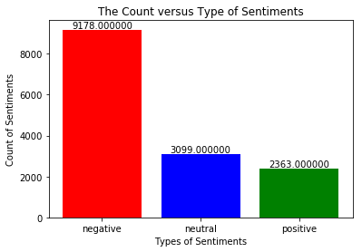

```python
# Group by airline_sentiment
df_processed = df.groupby("airline_sentiment")["airline_sentiment"].count().to_dict()

# Add on the values of y-axis into the plot
def autolabel(rects):
    for rect in rects:
        height = rect.get_height()
        ax.text(rect.get_x() + rect.get_width()/2., height, '%f' % float(height),
                ha='center', va='bottom')

# Bar Chart
fig, ax = plt.subplots()
index = list(df_processed.keys())
_bar=ax.bar(index, list(df_processed.values()), color=['r','b','g','y'])
plt.xticks(index, list(df_processed.keys()), rotation=0)
plt.xlabel('Types of Sentiments')
plt.ylabel('Count of Sentiments')
plt.title('The Count versus Type of Sentiments')
autolabel(_bar)
plt.show()
```

### *2. Bar Chart: The Count of Sentiments versus Airlines grouped by Types of Sentiments*

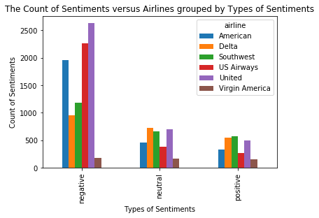

```python
# Group by airline_sentiment and airline
df_processed = df.groupby(["airline", "airline_sentiment"]).count().iloc[:,0].unstack(0)

# Bar Chart
chart = df_processed.plot(kind='bar',title = 'The Count of Sentiments versus Airlines grouped by Types of Sentiments')
chart.set_xlabel('Types of Sentiments')
chart.set_ylabel('Count of Sentiments')
plt.show()
```

### *3. Pie Chart: The distribution of Sentiments among All Negative Reasons*

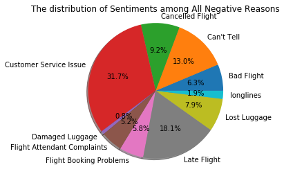

```python
# Group by negativereason
df_processed = df.groupby("negativereason")["negativereason"].count().to_dict()

# Pie chart, where the slices will be ordered and plotted counter-clockwise:
fig, ax = plt.subplots()
ax.pie(list(df_processed.values()), labels=list(df_processed.keys()), autopct='%1.1f%%', shadow=True, startangle=0)
ax.axis('equal')  # Equal aspect ratio ensures that pie is drawn as a circle.
plt.title('The distribution of Sentiments among All Negative Reasons')
plt.show()
```

### *4. Bar Chart: The distribution of Sentiments versus Negative Reasons grouped by Airlines*

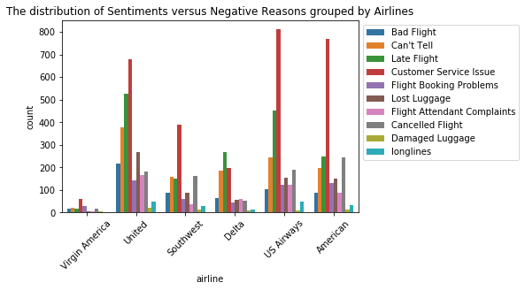

```python
# Bar Chart
sns.countplot(x = df['airline'], hue= df['negativereason'])
plt.xticks(rotation=45)
plt.legend(loc='upper left', bbox_to_anchor = (1,1))
plt.title('The distribution of Sentiments versus Negative Reasons grouped by Airlines')
plt.show()
```

### *5. Bar Chart: The Count of Negative Sentiments versus Airlines grouped by Date*

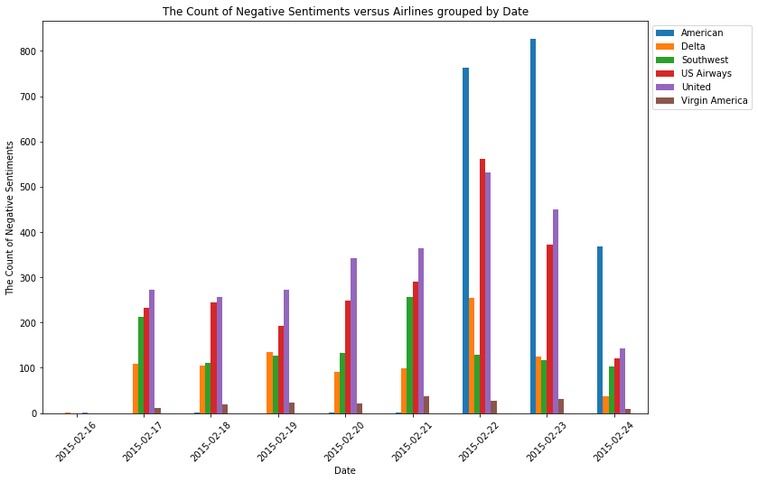

```python
# Converting datetime column to pandas datetime format and keeping only date
df['date'] = pd.to_datetime(df['tweet_created'])
df['date'] = df['date'].apply(lambda x : x.date())

# Bar Chart
df_processed = df.groupby(['date','airline','airline_sentiment']).size()
df_processed = df_processed.loc(axis=0)[:,:,'negative']
axis = df_processed.groupby(['date', 'airline']).sum().unstack().plot(kind='bar', figsize=(12,8), rot=45)
axis.set_ylabel('The Count of Negative Sentiments')
axis.set_xlabel('Date')
axis.legend(loc='upper left', bbox_to_anchor = (1,1))
plt.title('The Count of Negative Sentiments versus Airlines grouped by Date')
plt.show()
```

## **Part 4: Model Prediction**

### *Experiment 1 : Compare the results of modelling different datasets processed using different lemmatizers or stemmers with Random Forest (a machine learning algorithm)*

__Text Preprocessing__

**1. Select required columns**

```python
## Select required columns

df_required=df[['airline_sentiment','text']]
df_required.head(5)
```

|  | airline_sentiment | text |
| --- | --- | --- |
| 0 | neutral | @VirginAmerica What @dhepburn said. |
| 1 | positive | @VirginAmerica plus you've added commercials t... |
| 2 | neutral | @VirginAmerica I didn't today... Must mean I n... |
| 3 | negative | @VirginAmerica it's really aggressive to blast... |
| 4 | negative | @VirginAmerica and it's a really big bad thing... |

**2. Perform some common text preprocessing algortihms**

```
- Remove empty reviews.
- Convert all the reviews to lower case.
- Remove numbers, tweet account names, website urls, special characters and white spaces.
```

```python
## Perform some common text preprocessing algortihms

def clean_text(dframe):
    # Drop the rows that do not contain any review
    dframe=dframe.dropna()
    # Convert all the reviews into lower case
    dframe['text']=dframe['text'].apply(lambda row : row.lower())
    # Remove numbers
    dframe['text']=dframe['text'].apply(lambda row : re.sub('\d+','',row))
    # Remove tweet account name
    dframe['text']=dframe['text'].apply(lambda row:re.sub(r'@\w+', '',row))
    # Remove website urls
    dframe['text']=dframe['text'].apply(lambda row:re.sub(r'http\S+', '',row))
    # Remove special characters
    dframe['text']=dframe['text'].apply(lambda row:re.sub(r"[^A-Za-z0-9']+", ' ',row))
    # Remove white spaces
    dframe['text']=dframe['text'].apply(lambda row:re.sub(r'\s+', ' ',row))
    # return dataframe
    return dframe

df_cleaned=clean_text(df_required)
df_cleaned.head(5)
```

|  | airline_sentiment | text |
| --- | --- | --- |
| 0 | neutral | what said |
| 1 | positive | plus you've added commercials to the experien... |
| 2 | neutral | i didn't today must mean i need to take anoth... |
| 3 | negative | it's really aggressive to blast obnoxious ent... |
| 4 | negative | and it's a really big bad thing about it |

**3. Text normalization - lemmatization and stemming (either one)**

```
- WordNet Lemmatization (with POS tag)
- WordNet Lemmatization (without POS tag)
- Poster Stemming
- Snowball Stemming
```

```python
## WordNet Lemmatization (with and without POS tag)

# Install required files
nltk.download('punkt')
nltk.download('wordnet')

# Initialize WordNet Lemmatizer
lem = WordNetLemmatizer()

# Function to get the POS tag of a word
def get_wordnet_pos(word):
    tag = nltk.pos_tag([word])[0][1][0].upper()
    tag_dict = {"J": wordnet.ADJ, "N": wordnet.NOUN, "V": wordnet.VERB, "R": wordnet.ADV}
    return tag_dict.get(tag, wordnet.NOUN)

# Function to perform the WordNet Lemmatization with POS tag
def lemmatization_without_POS(review):
    return ' '.join([lem.lemmatize(word) for word in nltk.word_tokenize(review)])

# Function to perform the WordNet Lemmatization without POS tag
def lemmatization_with_POS(review):
    return ' '.join([lem.lemmatize(word, get_wordnet_pos(word)) for word in nltk.word_tokenize(review)])

# Function to perform text normalization
def normalize_text(dframe, WordNetLem_Mode):
    if WordNetLem_Mode == "WordNet_POS":
        print("\n-----WordNetLemmatization_with_POS-----")
        dframe['text']=dframe['text'].apply(lambda x : lemmatization_with_POS(x))
    else:
        print("\n-----WordNetLemmatization_without_POS-----")
        dframe['text']=dframe['text'].apply(lambda x : lemmatization_without_POS(x))
    return dframe

# WordNet Lemmatization with POS tag
df_WordNetLem_POS=normalize_text(df_cleaned, "WordNet_POS")
print(df_WordNetLem_POS.head(5))

# WordNet Lemmatization without POS tag
df_WordNetLem_NoPOS=normalize_text(df_cleaned, "WordNet_NoPOS")
print(df_WordNetLem_POS.head(5))
```

```
-----WordNetLemmatization_with_POS-----
  airline_sentiment                                               text
0           neutral                                           what say
1          positive  plus you 've add commercial to the experience ...
2           neutral  i do n't today must mean i need to take anothe...
3          negative  it 's really aggressive to blast obnoxious ent...
4          negative          and it 's a really big bad thing about it

-----WordNetLemmatization_without_POS-----
  airline_sentiment                                               text
0           neutral                                           what say
1          positive  plus you 've add commercial to the experience ...
2           neutral  i do n't today must mean i need to take anothe...
3          negative  it 's really aggressive to blast obnoxious ent...
4          negative          and it 's a really big bad thing about it
```

```python
## Poster Stemming

# Initialize Poster Stemmer
ps = PorterStemmer()

# Function to perform Poster Stemmer
def _PosterStemmer(review):
    return ' '.join([ps.stem(word) for word in nltk.word_tokenize(review)])

# Function to perform text normalization
def normalize_text(dframe):
    dframe['text']=dframe['text'].apply(lambda x : _PosterStemmer(x))
    return dframe

df_ps=normalize_text(df_cleaned)
df_ps.head(5)
```

|  | airline_sentiment | text |
| --- | --- | --- |
| 0 | neutral | what say |
| 1 | positive | plu you 've add commerci to the experi tacki |
| 2 | neutral | i do n't today must mean i need to take anoth ... |
| 3 | negative | it 's realli aggress to blast obnoxi entertain... |
| 4 | negative | and it 's a realli big bad thing about it |

```python
## Snowball Stemming

# Initialize Snowball Stemmer
ss = SnowballStemmer("english")

# Function to perform Snowball Stemmer
def _SnowballStemmer(review):
    return ' '.join([ss.stem(word) for word in nltk.word_tokenize(review)])

# Function to perform text normalization
def normalize_text(dframe):
    dframe['text']=dframe['text'].apply(lambda x : _SnowballStemmer(x))
    return dframe

df_ss=normalize_text(df_cleaned)
df_ss.head(5)
```

|  | airline_sentiment | text |
| --- | --- | --- |
| 0 | neutral | what say |
| 1 | positive | plu you ve add commerci to the experi tacki |
| 2 | neutral | i do n't today must mean i need to take anoth ... |
| 3 | negative | it 's realli aggress to blast obnoxi entertain... |
| 4 | negative | and it 's a realli big bad thing about it |

**4. Convert text to numeric values using TF-IDF vectorizer**

```python
## Convert text to numeric values using TF-IDF Vectorizer

# Function to perform TF-IDF Vectorizer (inlcuding removing stop words)
def _tfidconverter(_dframe):
    tfidfconverter = TfidfVectorizer(ngram_range=(1,2), stop_words='english')
    x = tfidfconverter.fit_transform(_dframe['text']).toarray()
    y = _dframe['airline_sentiment'].values
    return x, y
```

```python
## Perform TF-Vectorization to Non-augmented Data

# WordNet Lemmatizer wtih POS tag
WordNetLem_POS_x, WordNetLem_POS_y = _tfidconverter(df_WordNetLem_POS)

# WordNet Lemmatizer wtihout POS tag
WordNetLem_NoPOS_x, WordNetLem_NoPOS_y = _tfidconverter(df_WordNetLem_NoPOS)

# Poster Stemmer
sp_x, sp_y = _tfidconverter(df_ps)

# Snowball Stemmer
ss_x, ss_y = _tfidconverter(df_ss)
```

__Modelling - Random Forest__

```python
## Initialize the function of plotting the confusion matrix

# Function to plot confusion matrix
def plot_confusion_matrix(y_true, y_pred, classes, normalize=False, title=None, cmap=plt.cm.Blues):
    cm = confusion_matrix(y_true, y_pred)
    fig, ax = plt.subplots()
    im = ax.imshow(cm, interpolation='nearest', cmap=cmap)
    ax.figure.colorbar(im, ax=ax)
    ax.set(xticks=np.arange(cm.shape[1]), yticks=np.arange(cm.shape[0]), xticklabels=classes, yticklabels=classes, title=title, ylabel='True label', xlabel='Predicted label')
    plt.setp(ax.get_xticklabels(), rotation=45, ha="right", rotation_mode="anchor")
    thresh = cm.max() / 2.0
    for i in range(cm.shape[0]):
        for j in range(cm.shape[1]):
            ax.text(j, i, format(cm[i, j], 'd'),
                    ha="center", va="center",
                    color="white" if cm[i, j] > thresh else "black")
    fig.tight_layout()
    return ax
```

```python
## Initialize the function of modelling

# Function for modelling with Random Forest
def RF_modelling(X, Y, name):
    print("------{}-------".format(name))
    # Train-Test Split with ratio 80%:20%
    X_train, X_test, y_train, y_test = train_test_split(X, Y, test_size=0.2, random_state=50)
    # Initialize the classifier
    text_classifier = RandomForestClassifier(n_estimators=400,n_jobs=-1,verbose=True)
    # Fit the training data for modelling
    text_classifier.fit(X_train, y_train)
    # Make prediction using testing data
    predictions = text_classifier.predict(X_test)
    # Print the classification Report
    print("Classification Report :\n {}".format(classification_report(y_test,predictions)))
    # Print the Accuracy Score
    print("Model Accuracy: {}".format(accuracy_score(y_test, predictions)))
    # Print the Confusion Matrix
    plot_confusion_matrix(y_test, predictions, classes=['negative','neutral','positive'], title='Confusion Matrix')
    # return accuracy score for later comparison
    return accuracy_score(y_test, predictions)

# Get all the accuracy scores for different Lemmatizers and Stemmers
AccuracyScores = {"WdNet Lem with POS": 0.0,
                  "WdNet Lem without POS": 0.0,
                  "Poster Stemming":0.0,
                  "Snowball Stemming":0.0}
```

```
------WdNet Lem with POS-------
```

```
[Parallel(n_jobs=-1)]: Using backend ThreadingBackend with 80 concurrent workers.
[Parallel(n_jobs=-1)]: Done  40 tasks      | elapsed:   33.8s
[Parallel(n_jobs=-1)]: Done 400 out of 400 | elapsed:  2.6min finished
[Parallel(n_jobs=80)]: Using backend ThreadingBackend with 80 concurrent workers.
[Parallel(n_jobs=80)]: Done  40 tasks      | elapsed:    0.1s
[Parallel(n_jobs=80)]: Done 400 out of 400 | elapsed:    0.4s finished
```

```
Classification Report :
               precision    recall  f1-score   support

    negative       0.78      0.93      0.85      1835
     neutral       0.64      0.42      0.51       610
    positive       0.79      0.54      0.64       483

   micro avg       0.76      0.76      0.76      2928
   macro avg       0.74      0.63      0.67      2928
weighted avg       0.75      0.76      0.74      2928

Model Accuracy: 0.7619535519125683
```

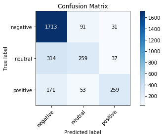

```python
## Modelling - WordNet Lemmatizer wtih POS tag

name="WdNet Lem with POS"
AccuracyScores[name] = RF_modelling(WordNetLem_POS_x, WordNetLem_POS_y, name)
```

```
------WdNet Lem without POS-------
```

```
[Parallel(n_jobs=-1)]: Using backend ThreadingBackend with 80 concurrent workers.
[Parallel(n_jobs=-1)]: Done  40 tasks      | elapsed:   28.4s
[Parallel(n_jobs=-1)]: Done 400 out of 400 | elapsed:  2.0min finished
[Parallel(n_jobs=80)]: Using backend ThreadingBackend with 80 concurrent workers.
[Parallel(n_jobs=80)]: Done  40 tasks      | elapsed:    0.1s
[Parallel(n_jobs=80)]: Done 400 out of 400 | elapsed:    0.4s finished
```

```
Classification Report :
               precision    recall  f1-score   support

    negative       0.78      0.93      0.85      1835
     neutral       0.64      0.42      0.51       610
    positive       0.79      0.53      0.63       483

   micro avg       0.76      0.76      0.76      2928
   macro avg       0.73      0.63      0.66      2928
weighted avg       0.75      0.76      0.74      2928

Model Accuracy: 0.7592213114754098
```

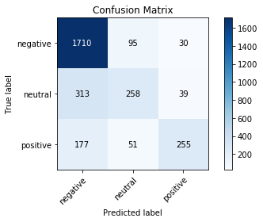

```python
## Modelling - WordNet Lemmatizer wtih POS tag

name="WdNet Lem without POS"
AccuracyScores[name] = RF_modelling(WordNetLem_NoPOS_x, WordNetLem_NoPOS_y, name)
```

```
------Poster Stemming-------
```

```
[Parallel(n_jobs=-1)]: Using backend ThreadingBackend with 80 concurrent workers.
[Parallel(n_jobs=-1)]: Done  40 tasks      | elapsed:   29.9s
[Parallel(n_jobs=-1)]: Done 400 out of 400 | elapsed:  2.2min finished
[Parallel(n_jobs=80)]: Using backend ThreadingBackend with 80 concurrent workers.
[Parallel(n_jobs=80)]: Done  40 tasks      | elapsed:    0.1s
[Parallel(n_jobs=80)]: Done 400 out of 400 | elapsed:    0.3s finished
```

```
Classification Report :
               precision    recall  f1-score   support

    negative       0.78      0.93      0.85      1835
     neutral       0.64      0.43      0.52       610
    positive       0.80      0.53      0.64       483

   micro avg       0.76      0.76      0.76      2928
   macro avg       0.74      0.63      0.67      2928
weighted avg       0.75      0.76      0.74      2928

Model Accuracy: 0.7602459016393442
```

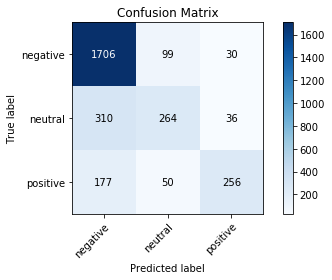

```python
## Modelling - Poster Stemming

name="Poster Stemming"
AccuracyScores[name] = RF_modelling(sp_x, sp_y, name)
```

```
------Snowball Stemming-------
```

```
[Parallel(n_jobs=-1)]: Using backend ThreadingBackend with 80 concurrent workers.
[Parallel(n_jobs=-1)]: Done  40 tasks      | elapsed:   21.3s
[Parallel(n_jobs=-1)]: Done 400 out of 400 | elapsed:  1.8min finished
[Parallel(n_jobs=80)]: Using backend ThreadingBackend with 80 concurrent workers.
[Parallel(n_jobs=80)]: Done  40 tasks      | elapsed:    0.1s
[Parallel(n_jobs=80)]: Done 400 out of 400 | elapsed:    0.4s finished
```

```
Classification Report :
               precision    recall  f1-score   support

    negative       0.78      0.93      0.85      1835
     neutral       0.63      0.42      0.51       610
    positive       0.77      0.53      0.63       483

   micro avg       0.76      0.76      0.76      2928
   macro avg       0.73      0.63      0.66      2928
weighted avg       0.75      0.76      0.74      2928

Model Accuracy: 0.7581967213114754
```

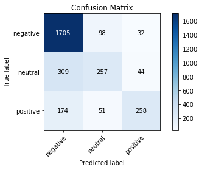

```python
## Modelling - Snowball Stemming

name="Snowball Stemming"
AccuracyScores[name] = RF_modelling(ss_x, ss_y, name)
```

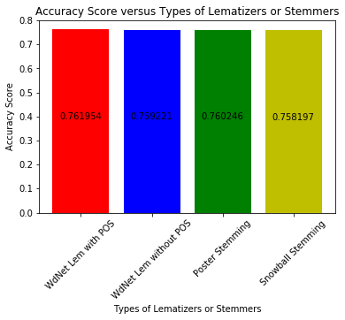

```python
## Compare the results of modelling different datasets processed using different lemmatizers or stemmers
## with Random Forest (a machine learning algorithm)

## The settings of best model will be used in next experiment

# Add on the values of y-axis into the plot
def autolabel(rects):
    for rect in rects:
        height = rect.get_height()
        ax.text(rect.get_x() + rect.get_width()/2., 0.5*height, '%f' % float(height),
                ha='center', va='bottom')

# Plot the results of comparison
fig, ax = plt.subplots()
index = list(range(len(list(AccuracyScores.keys()))))
_bar=ax.bar(index, list(AccuracyScores.values()), color=['r','b','g','y'])
plt.xticks(index, list(AccuracyScores.keys()), rotation=45)
plt.xlabel('Types of Lematizers or Stemmers')
plt.ylabel('Accuracy Score')
plt.title('Accuracy Score versus Types of Lematizers or Stemmers')
autolabel(_bar)
plt.show()
```

### *Experiment 2 - Compare the results of modelling augmented and non-augmented datasets*

__Text Preprocessing__

**Step 1 to 3 in Experiment 1 are repeated.**

```python
## Select the dataset processed by the best lemmatizer or stemmer

df_after_lem_and_stem=[df_WordNetLem_POS, df_WordNetLem_NoPOS, df_ps, df_ss]
df_best_lem_and_stem_dataset = df_after_lem_and_stem[np.argmax(list(AccuracyScores.values()))]
df_best_lem_and_stem_acc_score=max(list(AccuracyScores.values()))
print(np.argmax(list(AccuracyScores.values())))
```

```
0
```

**4. Upsample the number of reviews in the minor classess through data augmentation**

```python
## Upsample minor classes through Data Augmentation

# Install required file
nltk.download('averaged_perceptron_tagger')

# Function to upsample the minor classes through data augmentation
def augment_text(dataframe):
    # Select the targeted columns
    augmented_df = pd.DataFrame(columns=['text', 'airline_sentiment'])
    # Initialize the augmentor
    augmentor=nlpaug_augmenter_word.WordNetAug(aug_p=0.5)
    # Initlialize the ratio of upsampling
    aug_sent={'neutral':3, 'positive':4}
    # Perform the upsampling task according to the settings
    for i in range(len(dataframe)):
        current_label=dataframe['airline_sentiment'].iloc[i]
        if current_label in list(aug_sent.keys()):
            current_text=dataframe['text'].iloc[i]
            for j in range(aug_sent[current_label]):
                text = augmentor.augment(current_text)
                label = current_label
                tempdf = pd.DataFrame(list(zip([text], [label])), columns=['text', 'airline_sentiment'])
                augmented_df = augmented_df.append(tempdf)
        else :
                text = dataframe['text'].iloc[i]
                label = current_label
                tempdf = pd.DataFrame(list(zip([text], [label])), columns=['text', 'airline_sentiment'])
                augmented_df = augmented_df.append(tempdf)
    # Return the upsampled dataset
    return augmented_df

## Upsample the dataset
df_Aug=augment_text(df_best_lem_and_stem_dataset)
```

**5. Convert text to numeric values using TF-IDF vectorizer**

```python
## Perform TF-Vectorization to Augmented Data

df_Aug_x, df_Aug_y = _tfidconverter(df_Aug)
```

__Modelling - Random Forest__

```python
## Get all the accuracy scores for Augmented and Non_Augmented Dataset Modeling
try:
    AccuracyScores2 = {"Augmented": 0.0, "Non-Augmented": df_best_lem_and_stem_acc_score}
except:
    AccuracyScores2 = {"Augmented": 0.0, "Non-Augmented": 0.0}
```

```
------Augmented-------
```

```
[Parallel(n_jobs=-1)]: Using backend ThreadingBackend with 80 concurrent workers.
[Parallel(n_jobs=-1)]: Done  40 tasks      | elapsed:  1.9min
[Parallel(n_jobs=-1)]: Done 400 out of 400 | elapsed:  8.4min finished
[Parallel(n_jobs=80)]: Using backend ThreadingBackend with 80 concurrent workers.
[Parallel(n_jobs=80)]: Done  40 tasks      | elapsed:    0.2s
[Parallel(n_jobs=80)]: Done 400 out of 400 | elapsed:    0.9s finished
```

```
Classification Report :
               precision    recall  f1-score   support

    negative       0.88      0.90      0.89      1852
     neutral       0.81      0.86      0.83      1802
    positive       0.91      0.83      0.87      1932

   micro avg       0.86      0.86      0.86      5586
   macro avg       0.87      0.86      0.86      5586
weighted avg       0.87      0.86      0.86      5586

Model Accuracy: 0.8643036161833154
```

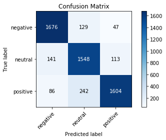

```python
## Modelling - Augmented
name="Augmented"
AccuracyScores2[name] = RF_modelling(df_Aug_x, df_Aug_y, name)
```

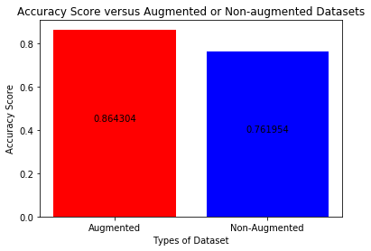

```python
## Compare the results of modelling augmented and non-augmented datasets with Random Forest

## The settings of best model will be used in next experiment

# Plot the results of comparison
fig, ax = plt.subplots()
index = list(range(len(list(AccuracyScores2.keys()))))
_bar=ax.bar(index, list(AccuracyScores2.values()), color=['r','b','g','y'])
plt.xticks(index, list(AccuracyScores2.keys()), rotation=0)
plt.xlabel('Types of Dataset')
plt.ylabel('Accuracy Score')
plt.title('Accuracy Score versus Augmented or Non-augmented Datasets')
autolabel(_bar)
plt.show()
```

### *Experiment 3 - Compare the results of modelling augmented dataset with machine or deep learning algorithms*

__Text Preprocessing__

**Step 1 to 4 in Experiment 2 are repeated.**

```python
## Select the best dataset in experiment 2.

best_df_in_ML=[df_Aug, df_best_lem_and_stem_dataset]
best_df_in_ML_dataset = best_df_in_ML[np.argmax(list(AccuracyScores2.values()))]
best_df_in_ML_acc_score=max(list(AccuracyScores2.values()))
print(np.argmax(list(AccuracyScores2.values())))
```

```
0
```

**5. Transform the dataset for loading into deep learning model on Keras Framework**

```python
## Convert categorical variables into dummy/indicator variables.

ycat=pd.get_dummies(best_df_in_ML_dataset['airline_sentiment']).values
print(ycat)
```

```
[[0 1 0]
 [0 1 0]
 [0 1 0]
 ...
 [0 1 0]
 [0 1 0]
 [0 1 0]]
```

```python
## Convert dataframe into list

xcat=best_df_in_ML_dataset['text'].values
print(xcat)
```

```
['what state' 'what order' 'what enounce' ...
 'we have ppl so we need know how mani tush be on the future flying plz assign u on standbi for peopl on the succeeding escape'
 'we have got ppl so we need bed how mani seat follow on the next flight of steps plz place uranium on standbi for peopl on the next escape'
 'we have ppl so we need know how mani bum make up on the next flight plz set u on standbi for peopl on the next trajectory']
```

```python
## Tokenize the texts, train-test split

# Initialize the tokernizer
tk = Tokenizer()

# Fit the texts
tk.fit_on_texts(xcat)

# Transform each text in texts in a sequence of integers
X_seq = tk.texts_to_sequences(xcat)
print(X_seq[:5])

print("----------")

# Make the sequence of integers into same length.
X_pad = pad_sequences(X_seq, maxlen=100, padding='post')
print (X_pad)

# Train-test split
X_train, X_test, y_train, y_test = train_test_split(X_pad, ycat, test_size = 0.20, random_state = 50)
```

```
[[45, 82], [45, 747], [45, 3058], [526, 6, 90, 275, 34, 932, 1, 2, 192, 4781], [526, 6, 90, 275, 34, 932, 1, 2, 192, 4781]]
----------
[[  45   82    0 ...    0    0    0]
 [  45  747    0 ...    0    0    0]
 [  45 3058    0 ...    0    0    0]
 ...
 [  28   15 1035 ...    0    0    0]
 [  28   15 1333 ...    0    0    0]
 [  28   15 1035 ...    0    0    0]]
```

__Modelling - Different Neural Network Architectures__

```python
## Modelling with different neural network architectures

# Calculate the vocabulary size
vocabulary_size = len(tk.word_counts.keys())+1

# Architecture of self-designed Simple Neural Network
def simple_NN(num_class=3):
    model = Sequential()
    model.add(Embedding(vocabulary_size, 100, input_length=100))
    model.add(Flatten())
    model.add(Dense(num_class, activation='softmax'))
    model.compile(loss='categorical_crossentropy', optimizer='adam', metrics=['accuracy'])
    model.summary()
    history=model.fit(X_train,y_train,validation_data=(X_test,y_test),batch_size=32,epochs=10,verbose=True)
    return history, model

# Architecture of self-designed Recurrent Neural Network
def rnn_model(num_class=3):
    model = Sequential()
    model.add(Embedding(vocabulary_size, 128, input_length=100))
    model.add(LSTM(128))
    model.add(BatchNormalization())
    model.add(Dense(64, activation='relu'))
    model.add(BatchNormalization())
    model.add(Dense(num_class, activation='softmax'))
    model.summary()
    model.compile(loss='categorical_crossentropy', optimizer='adam', metrics=['accuracy'])
    history=model.fit(X_train,y_train,validation_data=(X_test,y_test),batch_size=32,epochs=10,verbose=True)
    return history, model

# Architecture of self-designed Convolutional Neural Network
def cnn_model(num_class=3):
    model = Sequential()
    model.add(Embedding(vocabulary_size, 128, input_length=100))
    model.add(Conv1D(1024, 3, padding='valid', activation='relu', strides=1))
    model.add(GlobalMaxPooling1D())
    model.add(BatchNormalization())
    model.add(Dense(2048, activation='relu'))
    model.add(BatchNormalization())
    model.add(Dense(num_class, activation='softmax'))
    model.summary()
    model.compile(loss='categorical_crossentropy', optimizer='adam', metrics=['accuracy'])
    history=model.fit(X_train,y_train,validation_data=(X_test,y_test),batch_size=32,epochs=10,verbose=True)
    return history, model
```

```python
## Get all the accuracy scores for Augmented and Non_Augmented Dataset Modeling

try:
    AccuracyScores3 = {"ML-RandomForest ": best_df_in_ML_acc_score, "DL-SNN": 0.0, "DL-RNN": 0.0, "DL-CNN": 0.0}
except:
    AccuracyScores3 = {"ML-RandomForest ": 0.0, "DL-SNN": 0.0, "DL-RNN": 0.0, "DL-CNN": 0.0}
```

```python
## Modelling - Simple Neural Network

name="DL-SNN"
history_SNN, model_SNN= simple_NN()
AccuracyScores3[name] = max(history_SNN.history["val_acc"])
```

```
WARNING:tensorflow:From /opt/conda/lib/python3.7/site-packages/tensorflow/python/framework/op_def_library.py:263: colocate_with (from tensorflow.python.framework.ops) is deprecated and will be removed in a future version.
Instructions for updating:
Colocations handled automatically by placer.
Model: "sequential_1"
_________________________________________________________________
Layer (type)                 Output Shape              Param #
=================================================================
embedding_1 (Embedding)      (None, 100, 100)          1229900
_________________________________________________________________
flatten_1 (Flatten)          (None, 10000)             0
_________________________________________________________________
dense_1 (Dense)              (None, 3)                 30003
=================================================================
Total params: 1,259,903
Trainable params: 1,259,903
Non-trainable params: 0
_________________________________________________________________
WARNING:tensorflow:From /opt/conda/lib/python3.7/site-packages/tensorflow/python/ops/math_ops.py:3066: to_int32 (from tensorflow.python.ops.math_ops) is deprecated and will be removed in a future version.
Instructions for updating:
Use tf.cast instead.
Train on 22341 samples, validate on 5586 samples
```

```python
## Modelling - Recurrent Neural Network

name="DL-RNN"
history_RNN, model_RNN = rnn_model()
AccuracyScores3[name] = max(history_RNN.history["val_acc"])
```

```
Model: "sequential_2"
_________________________________________________________________
Layer (type)                 Output Shape              Param #
=================================================================
embedding_2 (Embedding)      (None, 100, 128)          1574272
_________________________________________________________________
lstm_1 (LSTM)                (None, 128)               131584
_________________________________________________________________
batch_normalization_1 (Batch (None, 128)               512
_________________________________________________________________
dense_2 (Dense)              (None, 64)                8256
_________________________________________________________________
batch_normalization_2 (Batch (None, 64)                256
_________________________________________________________________
dense_3 (Dense)              (None, 3)                 195
=================================================================
Total params: 1,715,075
Trainable params: 1,714,691
Non-trainable params: 384
_________________________________________________________________
Train on 22341 samples, validate on 5586 samples
```

```python
## Modelling - Convolutional Neural Network

name="DL-CNN"
history_CNN, model_CNN = cnn_model()
AccuracyScores3[name] = max(history_CNN.history["val_acc"])
```

```
Model: "sequential_3"
_________________________________________________________________
Layer (type)                 Output Shape              Param #
=================================================================
embedding_3 (Embedding)      (None, 100, 128)          1574272
_________________________________________________________________
conv1d_1 (Conv1D)            (None, 98, 1024)          394240
_________________________________________________________________
global_max_pooling1d_1 (Glob (None, 1024)              0
_________________________________________________________________
batch_normalization_3 (Batch (None, 1024)              4096
_________________________________________________________________
dense_4 (Dense)              (None, 2048)              2099200
_________________________________________________________________
batch_normalization_4 (Batch (None, 2048)              8192
_________________________________________________________________
dense_5 (Dense)              (None, 3)                 6147
=================================================================
Total params: 4,086,147
Trainable params: 4,080,003
Non-trainable params: 6,144
_________________________________________________________________
WARNING:tensorflow:From /opt/conda/lib/python3.7/site-packages/tensorflow/python/ops/math_grad.py:102: div (from tensorflow.python.ops.math_ops) is deprecated and will be removed in a future version.
Instructions for updating:
Deprecated in favor of operator or tf.math.divide.
Train on 22341 samples, validate on 5586 samples
```

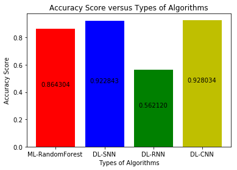

```python
## Compare the results of modelling augmented datasets with different algorithms

## The settings of best model will be used in next experiment

# Plot the results of comparison
fig, ax = plt.subplots()
index = list(range(len(list(AccuracyScores3.keys()))))
_bar=ax.bar(index, list(AccuracyScores3.values()), color=['r','b','g','y'])
plt.xticks(index, list(AccuracyScores3.keys()), rotation=0)
plt.xlabel('Types of Algorithms')
plt.ylabel('Accuracy Score')
plt.title('Accuracy Score versus Types of Algorithms')
autolabel(_bar)
plt.show()
```

__Visualization - The Performance of Best Algorithm__

```python
# Copy the information of algorithm

history = history_CNN
model = model_CNN
```

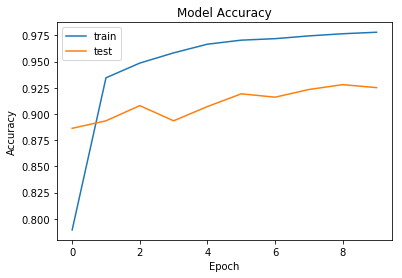

```python
## summarize history for accuracy

plt.plot(history.history['acc'])
plt.plot(history.history['val_acc'])
plt.title('Model Accuracy')
plt.ylabel('Accuracy')
plt.xlabel('Epoch')
plt.legend(['train', 'test'], loc='upper left')
plt.show()
```

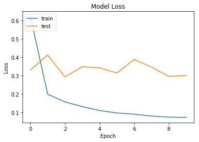

```python
# summarize history for loss

plt.plot(history.history['loss'])
plt.plot(history.history['val_loss'])
plt.title('Model Loss')
plt.ylabel('Loss')
plt.xlabel('Epoch')
plt.legend(['train', 'test'], loc='upper left')
plt.show()
```

```
Classification Report :
               precision    recall  f1-score   support

    negative       0.94      0.94      0.94      1827
     neutral       0.92      0.90      0.91      1821
    positive       0.92      0.94      0.93      1938

   micro avg       0.93      0.93      0.93      5586
   macro avg       0.93      0.92      0.93      5586
weighted avg       0.93      0.93      0.93      5586

Model Accuracy: 0.9251700680272109
```

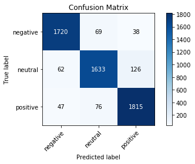

```python
## model testing

# Prediction
_predictions = [np.argmax(i) for i in model.predict(X_test)]
_y_test=[np.argmax(i) for i in y_test]

# Print the classification Report
print("Classification Report :\n {}".format(classification_report(_y_test,_predictions, target_names=['negative','neutral','positive'])))
# Print the Accuracy Score
print("Model Accuracy: {}".format(accuracy_score(_y_test, _predictions)))
# Print the Confusion Matrix
plot_confusion_matrix(_y_test, _predictions, classes=['negative','neutral','positive'], title='Confusion Matrix')

# Save the best model
model.save("best_model.h5")
```

## **Part 5: Word Cloud**

### *Negative Sentiments*

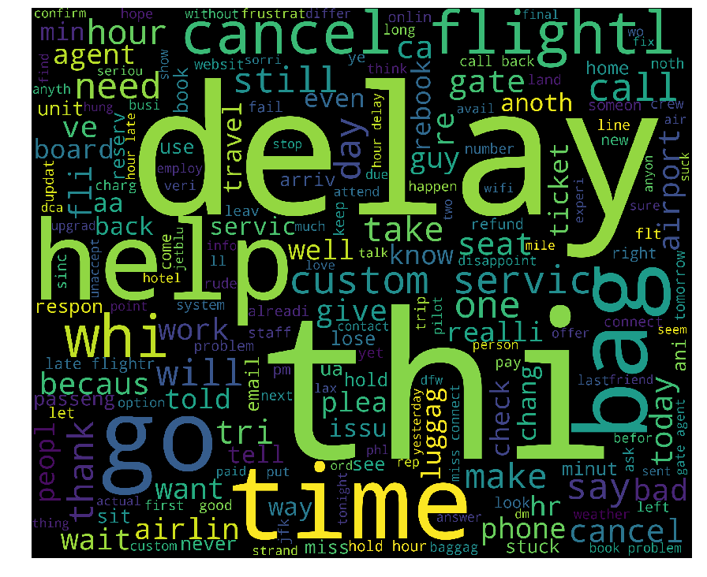

```python
## Generate the word cloud for negative sentiments

# Filter out the positive and neutral sentinments
df_negative = df_best_lem_and_stem_dataset[df_best_lem_and_stem_dataset['airline_sentiment']=='negative']

# Join all the words
cleaned_word = " ".join(df_negative['text'])

# Configure the stopwords
stopwords = set(STOPWORDS)
stopwords.add("amp")
stopwords.add("flight")
stopwords.add("united")
stopwords.add("plane")
stopwords.add("now")
stopwords.add("n\'t")

# Generate the word cloud
wordcloud = WordCloud(stopwords=stopwords, background_color='black', width=3000, height=2500).generate(cleaned_word)
plt.figure(1,figsize=(15, 15))
plt.imshow(wordcloud)
plt.axis('off')
plt.show()
```

### *Positive Sentiments*

```
<wordcloud.wordcloud.WordCloud object at 0x7f84f19d5160>
```

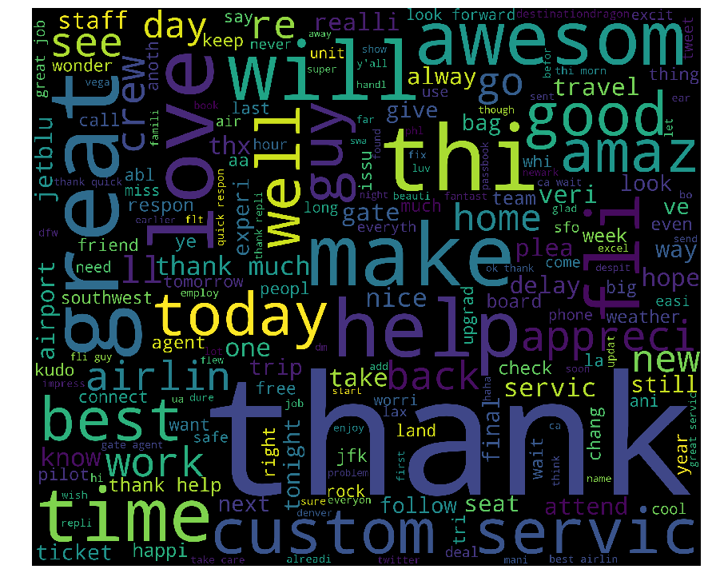

```python
## Generate the word cloud for positive sentiments

# Filter out the negative and neutral sentinments
df_positive = df_best_lem_and_stem_dataset[df_best_lem_and_stem_dataset['airline_sentiment']=='positive']

# Join all the words
cleaned_word = " ".join(df_positive['text'])

# Configure the stopwords
stopwords = set(STOPWORDS)
stopwords.add("amp")
stopwords.add("flight")
stopwords.add("united")
stopwords.add("plane")
stopwords.add("now")
stopwords.add("n\'t")

# Generate the word cloud
wordcloud = WordCloud(stopwords=stopwords, background_color='black', width=3000, height=2500).generate(cleaned_word)
print(wordcloud)
plt.figure(1,figsize=(15, 15))
plt.imshow(wordcloud)
plt.axis('off')
plt.show()
```